Report last updated Tue May 31 15:06:44 2016.

## Overview

The goal of this analysis is trying to put together GO terms, expression progiles, miRNA expression, and gene expression from the same data. Several files are generated to dig into Go enrichment analysis, genes and miRNAs are all together. The final figure intends to show the most populated GO terms and the most used miRNAs classified in different gene expression profiles.

It was used data from [RNAseq report](https://dl.dropboxusercontent.com/u/20050186/hsph/vishal_kidney/FA_mrna/mrna-summary.html#differential-expression) and [miRNA report](https://dl.dropboxusercontent.com/u/20050186/hsph/vishal_kidney/FA_small_rna/srna-summary.html#Differential_expression)

### Methods

Only considered genes and miRNAs with FDR < 5%. Targets from targetscan were filtered using total context score value of -0.1 or lower. This value correlates with the effect on the gene expression. In this case will be at leas 1% of effect. As well aggregate Pct should be higher of 0.1 that is the probability to be a real miRNA binding site for the gene.

I will cluster in common expression profiles with diana.

I will do GO enrichment analysis using only the genes that are de-regulated and are targeted by any miRNA (as well de-regulated) using targetscan database.

The universe for the analysis is all genes expressed in these samples. So, results from GO enrichment will mean that these genes are over represented compared to the expression profile of these samples.

```
Dimmension of cor matrix: 73 2987
GO enrichment with  22928  as universe ENSMUSG00000000001
and  778  as query: ENSMUSG00000029304
```

Tables with full information at : `go_terms_network.tsva` and `go_term_summary.tsv`.

### Summary of the GO enrichment classify by expression profiles.

Only miRNAs that appear more than 1 times are shown.

- Top-left panel shows the terms and the number of genes in that term with a specific expression profile(x axis). Bigger points mean more genes (number indicate number of genes).
- Bottom panel shows the different expression profiles detected. Profiles are in the same order than the top-left x axis labels.
- Top-right panel shows what miRNAs target what terms.

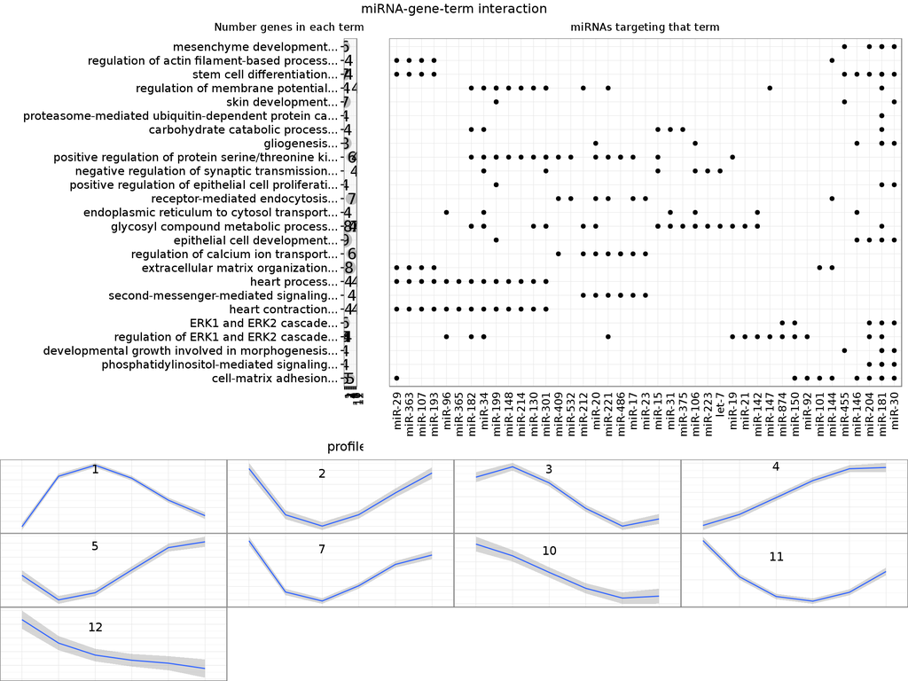

Table with summarized information for the figure at `interaction.tsv`.

# R Session Info